# NgWeeHerng_2214296_AIML_Regression

DAAA/FT/2A/01 P2214296 Ng Wee Herng CA1 Regression

##### **Background**

This is a dataset to predict the housing price in US based on various factors such as City, House Area, No. of bedrooms and toilets, renovation status, etc.

Importing libraries

```python
import numpy as np
import pandas as pd
import matplotlib.pyplot as plt
import seaborn as sns

from sklearn.compose import ColumnTransformer
from sklearn.preprocessing import FunctionTransformer, StandardScaler, OrdinalEncoder, OneHotEncoder

from sklearn.model_selection import (
    train_test_split,
    cross_validate,
    GridSearchCV,
    RandomizedSearchCV,
)
from sklearn import metrics

from sklearn.dummy import DummyRegressor
from sklearn.ensemble import GradientBoostingRegressor
from sklearn.linear_model import ElasticNet
from sklearn.linear_model import SGDRegressor
from sklearn.linear_model import BayesianRidge
from sklearn.linear_model import LinearRegression
from sklearn.ensemble import RandomForestRegressor
from sklearn.tree import DecisionTreeRegressor
from sklearn.linear_model import SGDRegressor
from sklearn.linear_model import Ridge
from sklearn.linear_model import Lasso

from imblearn.pipeline import Pipeline

import pickle
```

```python
data = pd.read_csv('housing_dataset.csv')
data
```

|  | House ID | City | House Area (sqm) | No. of Bedrooms | No. of Toilets | Stories | Renovation Status | Price ($) |
| --- | --- | --- | --- | --- | --- | --- | --- | --- |
| 0 | 0 | Chicago | 742.0 | 4 | 2 | 3 | furnished | 1330000 |
| 1 | 1 | Denver | 896.0 | 4 | 4 | 4 | furnished | 1225000 |
| 2 | 2 | Chicago | 996.0 | 3 | 2 | 2 | semi-furnished | 1225000 |
| 3 | 3 | Seattle | 750.0 | 4 | 2 | 2 | furnished | 1221500 |
| 4 | 4 | New York | 742.0 | 4 | 1 | 2 | furnished | 1141000 |
| ... | ... | ... | ... | ... | ... | ... | ... | ... |
| 540 | 540 | Seattle | 300.0 | 2 | 1 | 1 | unfurnished | 182000 |
| 541 | 541 | New York | 240.0 | 3 | 1 | 1 | semi-furnished | 176715 |
| 542 | 542 | Boston | 362.0 | 2 | 1 | 1 | unfurnished | 175000 |
| 543 | 543 | Seattle | 291.0 | 3 | 1 | 1 | furnished | 175000 |
| 544 | 544 | Chicago | 385.0 | 3 | 1 | 2 | unfurnished | 175000 |

545 rows × 8 columns

##### **Exploratory Data Analysis**

##### **Dataset Information**

This is a dataset collected from a property agent, it contains 545 entries with 8 columns

**House ID**: Unique identifier for a house ranging from 0 to 544  
**City**: Which city the house is located in  
**House Area**: Size of the house (in square metres)  
**No. of Bedrooms**: How many bedrooms the house has  
**No. of Toilets**: How many toilets the house has  
**Stories**: The number of stories in the house  
**Renovation Status**: How well the house is renovated  
**Price**: Price of the house (in USD)

```python
data.info()
```

```
<class 'pandas.core.frame.DataFrame'>
RangeIndex: 545 entries, 0 to 544
Data columns (total 8 columns):
 #   Column             Non-Null Count  Dtype
---  ------             --------------  -----
 0   House ID           545 non-null    int64
 1   City               545 non-null    object
 2   House Area (sqm)   545 non-null    float64
 3   No. of Bedrooms    545 non-null    int64
 4   No. of Toilets     545 non-null    int64
 5   Stories            545 non-null    int64
 6   Renovation Status  545 non-null    object
 7   Price ($)          545 non-null    int64
dtypes: float64(1), int64(5), object(2)
memory usage: 34.2+ KB
```

- We can see that the dataset has 545 entries with 8 columns
- The datatypes of all columns are numerical except for City, Renovation Status

```python
sns.set_style('darkgrid')
sns.set_palette('muted')
```

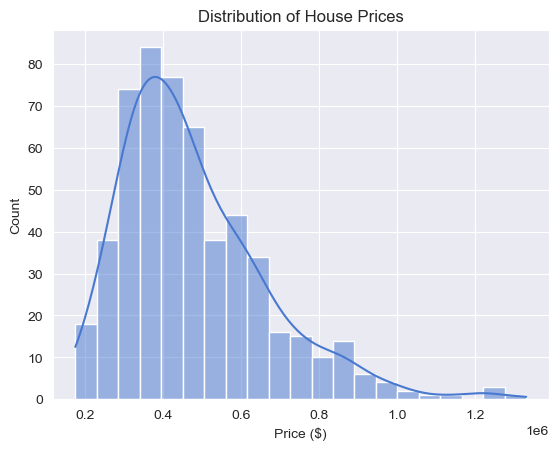

```python
sns.histplot(data=data, x='Price ($)', kde=True)
plt.title('Distribution of House Prices')
plt.show()
```

We can see that the house prices range from around 150000 USD to 1.3 million USD, with most of the houses in the dataset priced at around 400000 USD

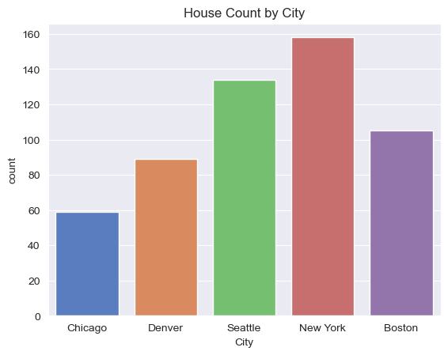

```python
sns.countplot(data=data, x='City')
plt.title('House Count by City')
plt.show()
```

In this dataset, we can see that the city with the most houses is New York, while the city with the least houses is Chicago

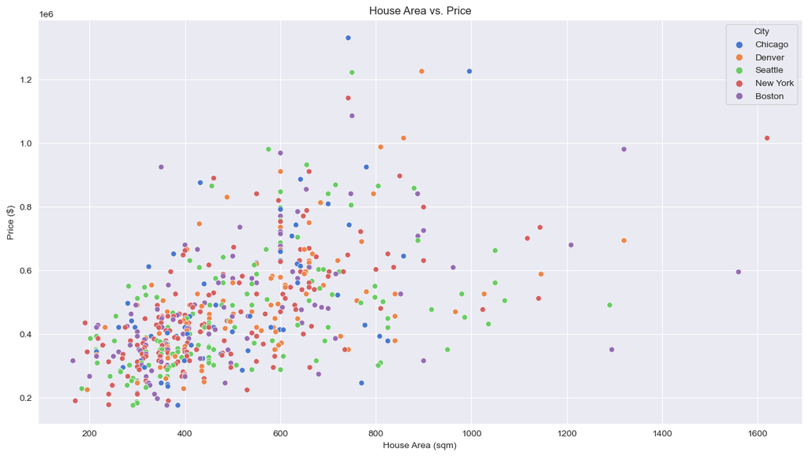

```python
fig, ax = plt.subplots(figsize=(15,8))
sns.scatterplot(data=data, x='House Area (sqm)', y='Price ($)', ax=ax, hue='City')
plt.title('House Area vs. Price')
plt.show()
```

We can see that as the house area increases, the price generally increases

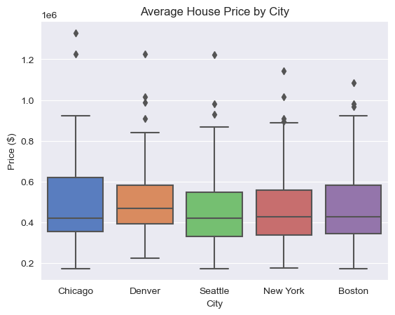

```python
sns.boxplot(data=data, x='City', y='Price ($)')
plt.title('Average House Price by City')
plt.show()
```

We can see that Denver has the highest meadian house price, and Seattle has the lowest average price.  
However, we this is not very representative as the number of bedrooms have to be factored in

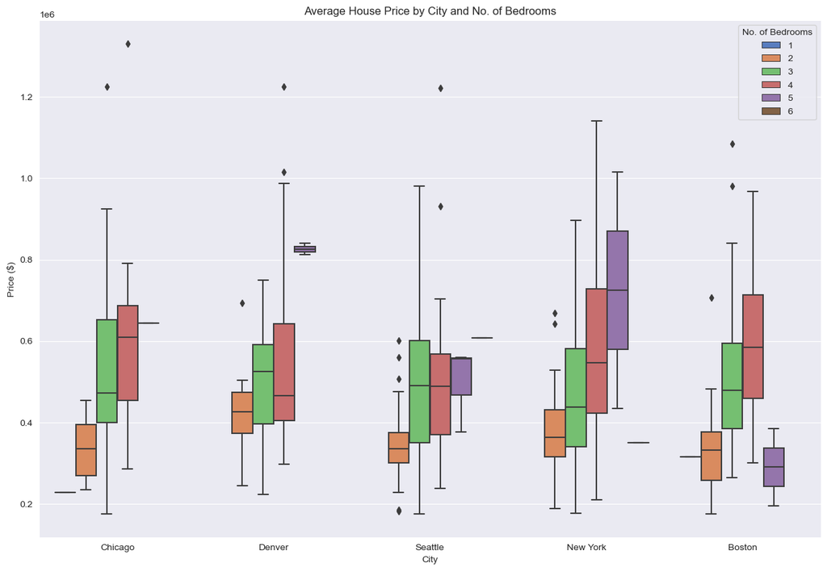

```python
fig, ax = plt.subplots(figsize=(15,10))
sns.boxplot(data=data, x='City', y='Price ($)', hue='No. of Bedrooms', ax=ax)
plt.title('Average House Price by City and No. of Bedrooms')
plt.show()
```

Here, we can actually see that New York is higher priced than supposedly thought from the boxplot above.

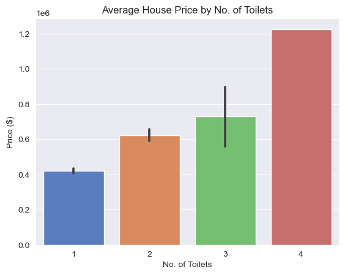

```python
sns.barplot(data=data, x='No. of Toilets', y='Price ($)')
plt.title('Average House Price by No. of Toilets')
plt.show()
```

We can see that as the number of toilets increases, the average house price increases, which tends to make sense

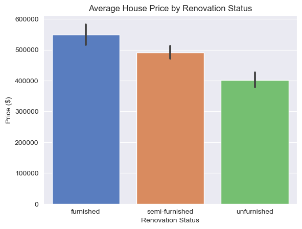

```python
sns.barplot(data=data, x='Renovation Status', y='Price ($)')
plt.title('Average House Price by Renovation Status')
plt.show()
```

We can see that furnished houses are sold for a higher price compared to unfurnished houses, which makes sense as renovation costs are factored into housing price

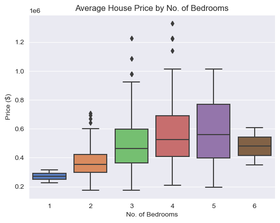

```python
sns.boxplot(data=data, x='No. of Bedrooms', y='Price ($)')
plt.title('Average House Price by No. of Bedrooms')
plt.show()
```

We see that actually 6 room houses are cheaper than 4 room and 5 room houses

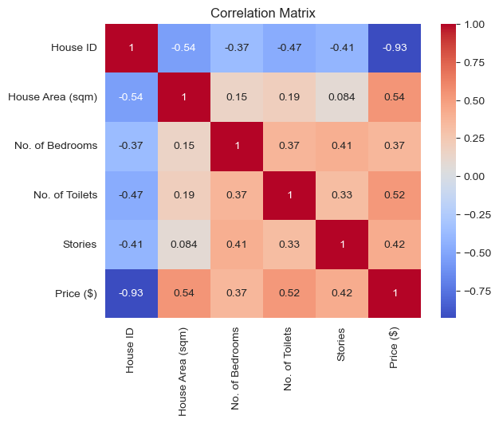

```python
corr_matrix = data.corr()
sns.heatmap(corr_matrix, annot=True, cmap='coolwarm')
plt.title('Correlation Matrix')
plt.show()
```

We can see that there is a positive correlation between most numerical columns against price, however the correlation is not that strong

```python
print(data.isna().sum())
```

```
House ID             0
City                 0
House Area (sqm)     0
No. of Bedrooms      0
No. of Toilets       0
Stories              0
Renovation Status    0
Price ($)            0
dtype: int64
```

We can see that there are no missing values in the dataset

#### **Feature Engineering**

**Looking at our features**

House ID is just an incremental number to identify each house, and is not a feature that will be helpful in determining the house price

```python
data = data.drop(['House ID'], axis=1)
data
```

|  | City | House Area (sqm) | No. of Bedrooms | No. of Toilets | Stories | Renovation Status | Price ($) |
| --- | --- | --- | --- | --- | --- | --- | --- |
| 0 | Chicago | 742.0 | 4 | 2 | 3 | furnished | 1330000 |
| 1 | Denver | 896.0 | 4 | 4 | 4 | furnished | 1225000 |
| 2 | Chicago | 996.0 | 3 | 2 | 2 | semi-furnished | 1225000 |
| 3 | Seattle | 750.0 | 4 | 2 | 2 | furnished | 1221500 |
| 4 | New York | 742.0 | 4 | 1 | 2 | furnished | 1141000 |
| ... | ... | ... | ... | ... | ... | ... | ... |
| 540 | Seattle | 300.0 | 2 | 1 | 1 | unfurnished | 182000 |
| 541 | New York | 240.0 | 3 | 1 | 1 | semi-furnished | 176715 |
| 542 | Boston | 362.0 | 2 | 1 | 1 | unfurnished | 175000 |
| 543 | Seattle | 291.0 | 3 | 1 | 1 | furnished | 175000 |
| 544 | Chicago | 385.0 | 3 | 1 | 2 | unfurnished | 175000 |

545 rows × 7 columns

We will split our dataset into two parts, one for the target variable y, and the rest are for features X

```python
X, y = data.drop("Price ($)", axis=1), data["Price ($)"]
```

#### **Train-Test-Split**

We are using train test split to split our dataset into two parts, one for training the model and one for testing the model. We will be using the 80:20 ratio

```python
X_train, X_test, y_train, y_test = train_test_split(
    X, y, test_size=0.2, shuffle=True, random_state=42
)
X_training = X_train.copy()
```

City and Renovation Status are not in numerical form, so we have to change it with the help of encoding

Ordinal Encoding

- Used for ordinal data
- Will use on Renovation Status

One Hot Encoding

- Used for nominal data
- Will use on City

Here, we specify the categories for the ordinal encoding (1 --> unfurnished, 2 --> semi-furnished, 3 --> furnished), and fit the data into the encoder to change it to numerical data

```python
data['Renovation Status'].unique()
```

```
array(['furnished', 'semi-furnished', 'unfurnished'], dtype=object)
```

```python
enc = OrdinalEncoder(categories=[[None, 'unfurnished', 'semi-furnished', 'furnished']])
X_training[["Renovation Status"]] = enc.fit_transform(X_training[["Renovation Status"]])
X_training
```

|  | City | House Area (sqm) | No. of Bedrooms | No. of Toilets | Stories | Renovation Status |
| --- | --- | --- | --- | --- | --- | --- |
| 46 | New York | 600.0 | 3 | 2 | 4 | 3.0 |
| 93 | Denver | 720.0 | 3 | 2 | 1 | 2.0 |
| 335 | Chicago | 381.6 | 2 | 1 | 1 | 3.0 |
| 412 | Boston | 261.0 | 3 | 1 | 2 | 1.0 |
| 471 | Seattle | 375.0 | 3 | 1 | 2 | 1.0 |
| ... | ... | ... | ... | ... | ... | ... |
| 71 | Boston | 600.0 | 4 | 2 | 4 | 1.0 |
| 106 | Seattle | 545.0 | 4 | 2 | 1 | 2.0 |
| 270 | Seattle | 450.0 | 3 | 2 | 3 | 3.0 |
| 435 | New York | 404.0 | 2 | 1 | 1 | 1.0 |
| 102 | Seattle | 550.0 | 3 | 2 | 4 | 2.0 |

436 rows × 6 columns

We found out during data analysis that the price of the house when there are 6 bedrooms is actually cheaper compared to 4 and 5 bedroom houses

We will be ordinal encoding our number of bedrooms so that the model can perform better to the data

```python
enc = OrdinalEncoder(categories=[[None, '1', '2', '3', '6', '4', '5']])
X_training["No. of Bedrooms"] = X_training["No. of Bedrooms"].astype(str)
X_training[["No. of Bedrooms"]] = enc.fit_transform(X_training[["No. of Bedrooms"]])
X_training
```

|  | City | House Area (sqm) | No. of Bedrooms | No. of Toilets | Stories | Renovation Status |
| --- | --- | --- | --- | --- | --- | --- |
| 46 | New York | 600.0 | 3.0 | 2 | 4 | 3.0 |
| 93 | Denver | 720.0 | 3.0 | 2 | 1 | 2.0 |
| 335 | Chicago | 381.6 | 2.0 | 1 | 1 | 3.0 |
| 412 | Boston | 261.0 | 3.0 | 1 | 2 | 1.0 |
| 471 | Seattle | 375.0 | 3.0 | 1 | 2 | 1.0 |
| ... | ... | ... | ... | ... | ... | ... |
| 71 | Boston | 600.0 | 5.0 | 2 | 4 | 1.0 |
| 106 | Seattle | 545.0 | 5.0 | 2 | 1 | 2.0 |
| 270 | Seattle | 450.0 | 3.0 | 2 | 3 | 3.0 |
| 435 | New York | 404.0 | 2.0 | 1 | 1 | 1.0 |
| 102 | Seattle | 550.0 | 3.0 | 2 | 4 | 2.0 |

436 rows × 6 columns

```python
enc = OneHotEncoder()
city_encoded = enc.fit_transform(X_training[["City"]]).toarray()

encoded_columns = enc.get_feature_names_out(["City"])
city_encoded = pd.DataFrame(city_encoded, columns=encoded_columns)

X_training.reset_index(drop=True, inplace=True)
city_encoded.reset_index(drop=True, inplace=True)

X_training_encoded = pd.concat([X_training.drop("City", axis=1), city_encoded], axis=1)
X_training_encoded
```

|  | House Area (sqm) | No. of Bedrooms | No. of Toilets | Stories | Renovation Status | City_Boston | City_Chicago | City_Denver | City_New York | City_Seattle |
| --- | --- | --- | --- | --- | --- | --- | --- | --- | --- | --- |
| 0 | 600.0 | 3.0 | 2 | 4 | 3.0 | 0.0 | 0.0 | 0.0 | 1.0 | 0.0 |
| 1 | 720.0 | 3.0 | 2 | 1 | 2.0 | 0.0 | 0.0 | 1.0 | 0.0 | 0.0 |
| 2 | 381.6 | 2.0 | 1 | 1 | 3.0 | 0.0 | 1.0 | 0.0 | 0.0 | 0.0 |
| 3 | 261.0 | 3.0 | 1 | 2 | 1.0 | 1.0 | 0.0 | 0.0 | 0.0 | 0.0 |
| 4 | 375.0 | 3.0 | 1 | 2 | 1.0 | 0.0 | 0.0 | 0.0 | 0.0 | 1.0 |
| ... | ... | ... | ... | ... | ... | ... | ... | ... | ... | ... |
| 431 | 600.0 | 5.0 | 2 | 4 | 1.0 | 1.0 | 0.0 | 0.0 | 0.0 | 0.0 |
| 432 | 545.0 | 5.0 | 2 | 1 | 2.0 | 0.0 | 0.0 | 0.0 | 0.0 | 1.0 |
| 433 | 450.0 | 3.0 | 2 | 3 | 3.0 | 0.0 | 0.0 | 0.0 | 0.0 | 1.0 |
| 434 | 404.0 | 2.0 | 1 | 1 | 1.0 | 0.0 | 0.0 | 0.0 | 1.0 | 0.0 |
| 435 | 550.0 | 3.0 | 2 | 4 | 2.0 | 0.0 | 0.0 | 0.0 | 0.0 | 1.0 |

436 rows × 10 columns

We will scale our data to make the values closer to each other with the help of StandardScaler() from sklearn

```python
num_col = [
    "House Area (sqm)"
]
scale = StandardScaler()

X_scale_train = X_training_encoded.copy()
X_scale_train[num_col] = scale.fit_transform(X_training_encoded[num_col])
X_scale_train
```

|  | House Area (sqm) | No. of Bedrooms | No. of Toilets | Stories | Renovation Status | City_Boston | City_Chicago | City_Denver | City_New York | City_Seattle |
| --- | --- | --- | --- | --- | --- | --- | --- | --- | --- | --- |
| 0 | 0.384168 | 3.0 | 2 | 4 | 3.0 | 0.0 | 0.0 | 0.0 | 1.0 | 0.0 |
| 1 | 0.929181 | 3.0 | 2 | 1 | 2.0 | 0.0 | 0.0 | 1.0 | 0.0 | 0.0 |
| 2 | -0.607755 | 2.0 | 1 | 1 | 3.0 | 0.0 | 1.0 | 0.0 | 0.0 | 0.0 |
| 3 | -1.155492 | 3.0 | 1 | 2 | 1.0 | 1.0 | 0.0 | 0.0 | 0.0 | 0.0 |
| 4 | -0.637730 | 3.0 | 1 | 2 | 1.0 | 0.0 | 0.0 | 0.0 | 0.0 | 1.0 |
| ... | ... | ... | ... | ... | ... | ... | ... | ... | ... | ... |
| 431 | 0.384168 | 5.0 | 2 | 4 | 1.0 | 1.0 | 0.0 | 0.0 | 0.0 | 0.0 |
| 432 | 0.134371 | 5.0 | 2 | 1 | 2.0 | 0.0 | 0.0 | 0.0 | 0.0 | 1.0 |
| 433 | -0.297097 | 3.0 | 2 | 3 | 3.0 | 0.0 | 0.0 | 0.0 | 0.0 | 1.0 |
| 434 | -0.506019 | 2.0 | 1 | 1 | 1.0 | 0.0 | 0.0 | 0.0 | 1.0 | 0.0 |
| 435 | 0.157080 | 3.0 | 2 | 4 | 2.0 | 0.0 | 0.0 | 0.0 | 0.0 | 1.0 |

436 rows × 10 columns

We will be implementing all our preprocesses in a pipeline to prevent data leakage

```python
X_train["No. of Bedrooms"] = X_train["No. of Bedrooms"].astype(str)
X_test['No. of Bedrooms'] = X_test["No. of Bedrooms"].astype(str)

preprocessor = ColumnTransformer(
    transformers=[
        ('standardize', StandardScaler(), ['House Area (sqm)']),
        ('ordinalfurnish', OrdinalEncoder(categories=[[None, 'unfurnished', 'semi-furnished', 'furnished']]), ['Renovation Status']),
        ('ordinalbedroom', OrdinalEncoder(categories=[[None, '1', '2', '3', '6', '4', '5']]), ['No. of Bedrooms']),
        ('onehot', OneHotEncoder(), ['City'])
    ],
    remainder='passthrough'  # Keep the remaining columns as they are
)

steps = [
    ("preprocessing", preprocessor),
    ("reg"),
]
step_num = len(steps) - 1
```

#### **Scoring Metrics**

I decided to evaluate my models on the r2 and rmse (root mean square error) metric.

- r2 represents the value of how much the independent variables are able to describe the value for the target variable.
- measures the error of the model in predicting the house price

```python
scoring_methods = [
    "r2",
    "neg_mean_squared_error",
    "neg_root_mean_squared_error",
    "neg_mean_absolute_error",
    "neg_mean_absolute_percentage_error"
]
```

I will use DummyRegressor as a baseline for our models

Note: We will be using 5 fold cross validation as the X_train only has 436 rows

```python
steps[step_num] = ("model", DummyRegressor(strategy="mean"))
dummy = Pipeline(steps=steps)
dummy.fit(X_train, y_train)
print(f"Baseline Accuracy Score :{dummy.score(X_test, y_test)}")
scores = cross_validate(
    dummy,
    X_train,
    y_train,
    cv=5,
    scoring=scoring_methods,
    n_jobs=4,
    return_train_score=True,
)
pd.DataFrame(scores)
```

```
Baseline Accuracy Score :-0.0179256794248297
```

|  | fit_time | score_time | test_r2 | train_r2 | test_neg_mean_squared_error | train_neg_mean_squared_error | test_neg_root_mean_squared_error | train_neg_root_mean_squared_error | test_neg_mean_absolute_error | train_neg_mean_absolute_error | test_neg_mean_absolute_percentage_error | train_neg_mean_absolute_percentage_error |
| --- | --- | --- | --- | --- | --- | --- | --- | --- | --- | --- | --- | --- |
| 0 | 0.007004 | 0.004511 | -0.003848 | 0.0 | -3.648590e+10 | -2.941183e+10 | -191012.826716 | -171498.768420 | -148023.086207 | -131201.476747 | -0.339765 | -0.307099 |
| 1 | 0.007020 | 0.004002 | -0.013833 | 0.0 | -3.021789e+10 | -3.100800e+10 | -173832.932243 | -176090.886956 | -128128.240227 | -135827.552877 | -0.273598 | -0.321479 |
| 2 | 0.010521 | 0.004513 | -0.125994 | 0.0 | -1.789207e+10 | -3.415970e+10 | -133761.225199 | -184823.441478 | -115456.473800 | -142343.983054 | -0.312576 | -0.329792 |
| 3 | 0.009521 | 0.005013 | -0.010766 | 0.0 | -3.666339e+10 | -2.940016e+10 | -191476.860101 | -171464.746460 | -142498.392978 | -132270.172659 | -0.309245 | -0.312737 |
| 4 | 0.007346 | 0.005001 | -0.001552 | 0.0 | -3.392335e+10 | -3.006640e+10 | -184182.930892 | -173396.641777 | -142895.322004 | -133495.626506 | -0.349901 | -0.309941 |

We can see that the test r2 is negative, which means the model is worse than a constant function at predicting house price

```python
regs = [('GradientBoostingRegressor', GradientBoostingRegressor()),
        ('ElasticNet', ElasticNet()),
        ('SGDRegressor', SGDRegressor()),
        ('BayesianRidge', BayesianRidge()),
        ('LinearRegression', LinearRegression()),
        ('RandomForestRegressor', RandomForestRegressor()),
        ('DecisionTreeRegressor', DecisionTreeRegressor()),
        ('Lasso', Lasso()),
        ('Ridge', Ridge())]
```

```python
def select_model(X_train, y_train, regs, scoring):
    # placeholder
    output = []
    # iterate through models
    for name, reg in regs:
        # creating temporary pipeline
        steps[step_num] = (name, reg)
        temp_pipeline = Pipeline(steps=steps)
        # cross validate
        score = cross_validate(
            temp_pipeline,
            X_train,
            y_train,
            scoring=scoring,
            n_jobs=3,
            verbose=1,
            cv=5,
            return_train_score=True,
        )
        # get the average score and then store in a Series
        output.append(pd.Series(score, name=name).apply(np.mean))
    return pd.DataFrame(output).sort_values(
        by=[
            "test_r2",
            "test_neg_root_mean_squared_error"
        ],
        ascending=False,
    )

model_scores = select_model(X_train, y_train, regs, scoring_methods)
```

```
[Parallel(n_jobs=3)]: Using backend LokyBackend with 3 concurrent workers.
[Parallel(n_jobs=3)]: Done   5 out of   5 | elapsed:    0.0s finished
[Parallel(n_jobs=3)]: Using backend LokyBackend with 3 concurrent workers.
[Parallel(n_jobs=3)]: Done   5 out of   5 | elapsed:    0.0s finished
[Parallel(n_jobs=3)]: Using backend LokyBackend with 3 concurrent workers.
[Parallel(n_jobs=3)]: Done   5 out of   5 | elapsed:    0.0s finished
[Parallel(n_jobs=3)]: Using backend LokyBackend with 3 concurrent workers.
[Parallel(n_jobs=3)]: Done   5 out of   5 | elapsed:    0.0s finished
[Parallel(n_jobs=3)]: Using backend LokyBackend with 3 concurrent workers.
[Parallel(n_jobs=3)]: Done   5 out of   5 | elapsed:    0.0s finished
[Parallel(n_jobs=3)]: Using backend LokyBackend with 3 concurrent workers.
[Parallel(n_jobs=3)]: Done   5 out of   5 | elapsed:    0.3s finished
[Parallel(n_jobs=3)]: Using backend LokyBackend with 3 concurrent workers.
[Parallel(n_jobs=3)]: Done   5 out of   5 | elapsed:    0.0s finished
[Parallel(n_jobs=3)]: Using backend LokyBackend with 3 concurrent workers.
[Parallel(n_jobs=3)]: Done   5 out of   5 | elapsed:    0.0s finished
[Parallel(n_jobs=3)]: Using backend LokyBackend with 3 concurrent workers.
[Parallel(n_jobs=3)]: Done   5 out of   5 | elapsed:    0.0s finished
```

Note that 5 fold cross validation is used as our dataset is small, with X-train only have 436 rows

```python
model_scores
```

|  | fit_time | score_time | test_r2 | train_r2 | test_neg_mean_squared_error | train_neg_mean_squared_error | test_neg_root_mean_squared_error | train_neg_root_mean_squared_error | test_neg_mean_absolute_error | train_neg_mean_absolute_error | test_neg_mean_absolute_percentage_error | train_neg_mean_absolute_percentage_error |
| --- | --- | --- | --- | --- | --- | --- | --- | --- | --- | --- | --- | --- |
| SGDRegressor | 0.006711 | 0.003968 | 0.516102 | 0.560969 | -1.445127e+10 | -1.352164e+10 | -119411.601648 | -116236.501092 | -87955.871140 | -84986.421135 | -0.190562 | -0.184477 |
| BayesianRidge | 0.008348 | 0.005206 | 0.516024 | 0.567892 | -1.444656e+10 | -1.331055e+10 | -119404.980865 | -115325.294888 | -87741.111295 | -84289.551473 | -0.194926 | -0.188140 |
| Ridge | 0.006312 | 0.004108 | 0.514310 | 0.568393 | -1.446915e+10 | -1.329512e+10 | -119528.034685 | -115258.467822 | -87918.475982 | -84292.441334 | -0.195004 | -0.187873 |
| Lasso | 0.009479 | 0.004409 | 0.513677 | 0.568416 | -1.448108e+10 | -1.329441e+10 | -119583.881100 | -115255.361760 | -87972.884476 | -84303.320485 | -0.195040 | -0.187824 |
| LinearRegression | 0.009118 | 0.006109 | 0.513672 | 0.568416 | -1.448122e+10 | -1.329441e+10 | -119584.490170 | -115255.361640 | -87973.545293 | -84303.407990 | -0.195041 | -0.187824 |
| GradientBoostingRegressor | 0.048207 | 0.004903 | 0.498656 | 0.826848 | -1.495158e+10 | -5.332341e+09 | -121151.899222 | -72974.974134 | -86637.303283 | -54409.420581 | -0.192985 | -0.125270 |
| RandomForestRegressor | 0.154408 | 0.011355 | 0.476734 | 0.932773 | -1.555317e+10 | -2.072020e+09 | -123921.845174 | -45475.277213 | -90334.805663 | -32850.260276 | -0.200752 | -0.073412 |
| ElasticNet | 0.006510 | 0.004503 | 0.466339 | 0.487723 | -1.630231e+10 | -1.577877e+10 | -126315.544156 | -125570.829560 | -93085.888671 | -91979.432650 | -0.212180 | -0.209932 |
| DecisionTreeRegressor | 0.006513 | 0.004004 | 0.060976 | 0.998786 | -2.530138e+10 | -3.679069e+07 | -158567.358182 | -5986.973057 | -115879.764629 | -823.761651 | -0.252976 | -0.002346 |

We will choose the first three models to tune as they have the highest test r2 score and the lower rmse

BayesianRidge()

```python
steps[step_num] = ("model", BayesianRidge())

br_reg = Pipeline(steps=steps)
br_reg.fit(X_train, y_train)
print(f"Model Accuracy Score :{br_reg.score(X_train, y_train)}")
scores = cross_validate(
    br_reg,
    X_train,
    y_train,
    cv=5,
    scoring=scoring_methods,
    n_jobs=4,
    return_train_score=True,
)
# displaying scores
display(
    pd.DataFrame(scores)
    .append(pd.Series(pd.DataFrame(scores).mean(), name="Mean"))
)
```

```
Model Accuracy Score :0.5646381535367904
```

|  | fit_time | score_time | test_r2 | train_r2 | test_neg_mean_squared_error | train_neg_mean_squared_error | test_neg_root_mean_squared_error | train_neg_root_mean_squared_error | test_neg_mean_absolute_error | train_neg_mean_absolute_error | test_neg_mean_absolute_percentage_error | train_neg_mean_absolute_percentage_error |
| --- | --- | --- | --- | --- | --- | --- | --- | --- | --- | --- | --- | --- |
| 0 | 0.013518 | 0.006518 | 0.568118 | 0.554857 | -1.569720e+10 | -1.309247e+10 | -125288.462241 | -114422.330166 | -92077.849224 | -83770.241879 | -0.207191 | -0.187279 |
| 1 | 0.015018 | 0.006018 | 0.548877 | 0.565786 | -1.344599e+10 | -1.346410e+10 | -115956.858045 | -116034.925103 | -84600.172207 | -84612.607009 | -0.185156 | -0.189584 |
| 2 | 0.015019 | 0.005518 | 0.433728 | 0.571065 | -8.998065e+09 | -1.465230e+10 | -94858.131974 | -121046.672149 | -73648.032291 | -88415.047385 | -0.180096 | -0.195182 |
| 3 | 0.016018 | 0.006519 | 0.493555 | 0.579518 | -1.837020e+10 | -1.236224e+10 | -135536.716955 | -111185.622538 | -95913.137027 | -81829.685398 | -0.198769 | -0.184806 |
| 4 | 0.007516 | 0.005008 | 0.535844 | 0.568235 | -1.572133e+10 | -1.298162e+10 | -125384.735110 | -113936.924481 | -92466.365726 | -82820.175692 | -0.203418 | -0.183846 |
| Mean | 0.013418 | 0.005916 | 0.516024 | 0.567892 | -1.444656e+10 | -1.331055e+10 | -119404.980865 | -115325.294888 | -87741.111295 | -84289.551473 | -0.194926 | -0.188140 |

Ridge()

```python
steps[step_num] = ("model", Ridge())

ridge_reg = Pipeline(steps=steps)
ridge_reg.fit(X_train, y_train)
print(f"Model Accuracy Score :{ridge_reg.score(X_train, y_train)}")
scores = cross_validate(
    ridge_reg,
    X_train,
    y_train,
    cv=5,
    scoring=scoring_methods,
    n_jobs=4,
    return_train_score=True,
)
# displaying scores
display(
    pd.DataFrame(scores)
    .append(pd.Series(pd.DataFrame(scores).mean(), name="Mean"))
)
```

```
Model Accuracy Score :0.5649699180400195
```

|  | fit_time | score_time | test_r2 | train_r2 | test_neg_mean_squared_error | train_neg_mean_squared_error | test_neg_root_mean_squared_error | train_neg_root_mean_squared_error | test_neg_mean_absolute_error | train_neg_mean_absolute_error | test_neg_mean_absolute_percentage_error | train_neg_mean_absolute_percentage_error |
| --- | --- | --- | --- | --- | --- | --- | --- | --- | --- | --- | --- | --- |
| 0 | 0.008015 | 0.004520 | 0.573226 | 0.555404 | -1.551153e+10 | -1.307638e+10 | -124545.277837 | -114351.994901 | -91516.941725 | -83857.143208 | -0.206184 | -0.187094 |
| 1 | 0.007515 | 0.004519 | 0.546959 | 0.566303 | -1.350316e+10 | -1.344808e+10 | -116203.079028 | -115965.847185 | -85261.388426 | -84517.856266 | -0.186283 | -0.189118 |
| 2 | 0.006515 | 0.004519 | 0.424588 | 0.571555 | -9.143307e+09 | -1.463554e+10 | -95620.643171 | -120977.452780 | -74260.329452 | -88366.942800 | -0.180741 | -0.194836 |
| 3 | 0.007516 | 0.005019 | 0.490471 | 0.579978 | -1.848207e+10 | -1.234873e+10 | -135948.778105 | -111124.831773 | -96252.675581 | -81843.517400 | -0.199230 | -0.184610 |
| 4 | 0.005501 | 0.003566 | 0.536305 | 0.568725 | -1.570570e+10 | -1.296688e+10 | -125322.395286 | -113872.212470 | -92301.044727 | -82876.746995 | -0.202584 | -0.183707 |
| Mean | 0.007013 | 0.004429 | 0.514310 | 0.568393 | -1.446915e+10 | -1.329512e+10 | -119528.034685 | -115258.467822 | -87918.475982 | -84292.441334 | -0.195004 | -0.187873 |

SGDRegressor()

```python
steps[step_num] = ("model", SGDRegressor())

sgd_reg = Pipeline(steps=steps)
sgd_reg.fit(X_train, y_train)
print(f"Model Accuracy Score :{sgd_reg.score(X_train, y_train)}")
scores = cross_validate(
    sgd_reg,
    X_train,
    y_train,
    cv=5,
    scoring=scoring_methods,
    n_jobs=4,
    return_train_score=True,
)
# displaying scores
display(
    pd.DataFrame(scores)
    .append(pd.Series(pd.DataFrame(scores).mean(), name="Mean"))
)
```

```
Model Accuracy Score :0.5627978965725098
```

|  | fit_time | score_time | test_r2 | train_r2 | test_neg_mean_squared_error | train_neg_mean_squared_error | test_neg_root_mean_squared_error | train_neg_root_mean_squared_error | test_neg_mean_absolute_error | train_neg_mean_absolute_error | test_neg_mean_absolute_percentage_error | train_neg_mean_absolute_percentage_error |
| --- | --- | --- | --- | --- | --- | --- | --- | --- | --- | --- | --- | --- |
| 0 | 0.007522 | 0.004019 | 0.580919 | 0.547821 | -1.523191e+10 | -1.329942e+10 | -123417.637326 | -115323.125030 | -88800.576409 | -84853.188146 | -0.193284 | -0.186313 |
| 1 | 0.007519 | 0.004019 | 0.544701 | 0.555769 | -1.357046e+10 | -1.377470e+10 | -116492.308443 | -117365.673741 | -86196.919983 | -85704.289469 | -0.184133 | -0.185381 |
| 2 | 0.007503 | 0.004020 | 0.425161 | 0.567766 | -9.134206e+09 | -1.476499e+10 | -95573.038145 | -121511.288824 | -73723.606575 | -88910.561590 | -0.176878 | -0.192103 |
| 3 | 0.007502 | 0.004019 | 0.487191 | 0.574937 | -1.860104e+10 | -1.249691e+10 | -136385.647953 | -111789.592474 | -97036.548170 | -82325.047997 | -0.197128 | -0.181098 |
| 4 | 0.006013 | 0.004001 | 0.520404 | 0.566112 | -1.624430e+10 | -1.304546e+10 | -127453.122356 | -114216.719337 | -94258.021117 | -83471.656786 | -0.204057 | -0.182659 |
| Mean | 0.007212 | 0.004016 | 0.511675 | 0.562481 | -1.455638e+10 | -1.347630e+10 | -119864.350845 | -116041.279881 | -88003.134451 | -85052.948798 | -0.191096 | -0.185511 |

```python
br_y_pred = br_reg.predict(X_test)
ridge_y_pred = ridge_reg.predict(X_test)
sgd_y_pred = sgd_reg.predict(X_test)
```

```python
test_scores_df = pd.DataFrame(columns=['Model', 'MSE', 'RMSE', 'MAE', 'MAPE', 'R2'])

def reg_report(model, y_test, y_pred):

    global test_scores_df

    new_row = {'Model': model,
               'MSE': metrics.mean_squared_error(y_test, y_pred),
               'RMSE': metrics.mean_squared_error(y_test, y_pred, squared = False),
               'MAE': metrics.mean_absolute_error(y_test, y_pred),
               'MAPE': metrics.mean_absolute_percentage_error(y_test, y_pred),
               'R2': metrics.r2_score(y_test, y_pred)}
    test_scores_df = pd.concat([test_scores_df, pd.DataFrame([new_row])], ignore_index=True)
    return test_scores_df

reg_report('BayesianRidge', y_test, br_y_pred)
reg_report('Ridge', y_test, ridge_y_pred)
reg_report('SGDRegressor', y_test, sgd_y_pred )
test_scores_df
```

|  | Model | MSE | RMSE | MAE | MAPE | R2 |
| --- | --- | --- | --- | --- | --- | --- |
| 0 | BayesianRidge | 2.435315e+10 | 156054.950724 | 118022.019410 | 0.261009 | 0.518195 |
| 1 | Ridge | 2.438545e+10 | 156158.418249 | 118474.071772 | 0.261904 | 0.517556 |
| 2 | SGDRegressor | 2.435109e+10 | 156048.356883 | 118364.716299 | 0.258635 | 0.518236 |

We can see that to unseen data, the r2 values are around 0.52 while the rmse is around 156,000 USD

Move on to tuning to try to improve scores

#### **Hyperparameter Tuning**

We will be using coarse to fine tuning for hyperparameter tuning

The steps are

1. Run RandomizedSearchCV on a range of parameters
2. Get optimal parameters
3. Run exhaustive search using GridSearchCV around the optimal parameters
4. Get optimal parameters

#### **Hyperparameter Tuning for BayesianRidge**

Getting parameters for BayesianRidge

```python
list(BayesianRidge().get_params().keys())
```

```
['alpha_1',
 'alpha_2',
 'alpha_init',
 'compute_score',
 'copy_X',
 'fit_intercept',
 'lambda_1',
 'lambda_2',
 'lambda_init',
 'n_iter',
 'tol',
 'verbose']
```

```python
BayesianRidge().get_params()
```

```
{'alpha_1': 1e-06,
 'alpha_2': 1e-06,
 'alpha_init': None,
 'compute_score': False,
 'copy_X': True,
 'fit_intercept': True,
 'lambda_1': 1e-06,
 'lambda_2': 1e-06,
 'lambda_init': None,
 'n_iter': 300,
 'tol': 0.001,
 'verbose': False}
```

Coarse Tuning with RandomizedSearchCV()

```python
# Create the parameter grid
parameters_coarse = {
    'n_iter': np.arange(200, 401, 25),
    'alpha_1': [1e-6, 1e-4, 1e-2, 1e-1, 1.0],
    'alpha_2': [1e-6, 1e-4, 1e-2, 1e-1, 1.0],
    'lambda_1': [1e-6, 1e-4, 1e-2, 1e-1, 1.0],
    'lambda_2': [1e-6, 1e-4, 1e-2, 1e-1, 1.0],
    'tol': [1e-5, 1e-3, 1.0, 5.0],
    'alpha_init':[1, 1.1, 1.2, 1.3, 1.4, 1.5, 1.9],
    'lambda_init': [1e-1, 1e-2, 1e-3, 1e-4, 1e-5, 1e-6, 1e-9]
}

# Creating a model based on the pipeline
steps[step_num] = (
    "hyper",
    RandomizedSearchCV(
        BayesianRidge(),
        parameters_coarse,
        cv=5,
        n_iter=60,
        verbose=1,
        n_jobs=-1,
        scoring="r2"
    ),
)

br_r_search = Pipeline(steps=steps)
# Fitting Model
br_r_search.fit(X_train, y_train)

print(br_r_search.named_steps["hyper"].best_estimator_)
print(br_r_search.named_steps["hyper"].best_params_)
print(br_r_search.named_steps["hyper"].best_score_)
```

```
Fitting 5 folds for each of 60 candidates, totalling 300 fits
BayesianRidge(alpha_1=0.0001, alpha_2=0.0001, alpha_init=1.3, lambda_1=1.0,
              lambda_init=0.1)
{'tol': 0.001, 'n_iter': 300, 'lambda_init': 0.1, 'lambda_2': 1e-06, 'lambda_1': 1.0, 'alpha_init': 1.3, 'alpha_2': 0.0001, 'alpha_1': 0.0001}
0.5164757308183946
```

```python
{'tol': 0.001, 'n_iter': 300, 'lambda_init': 0.1, 'lambda_2': 1e-06, 'lambda_1': 1.0, 'alpha_init': 1.3, 'alpha_2': 0.0001, 'alpha_1': 0.0001}
```

```
{'tol': 0.001,
 'n_iter': 300,
 'lambda_init': 0.1,
 'lambda_2': 1e-06,
 'lambda_1': 1.0,
 'alpha_init': 1.3,
 'alpha_2': 0.0001,
 'alpha_1': 0.0001}
```

Note that we did not set a random state for this and so results may vary if ran again, however we will be using the parameters above

Fine Tuning with GridSearchCV

```python
n_iter_grid = np.arange(br_r_search.named_steps["hyper"].best_params_['n_iter']-10, br_r_search.named_steps["hyper"].best_params_['n_iter']+10,1)

parameters_fine = {
    'n_iter': n_iter_grid,
    'alpha_1': [1e-3, 1e-4, 1e-5],
    'alpha_2': [1e-3, 1e-4, 1e-5],
    'lambda_1': np.arange(1e-1, 1.0, 0.05),
    'lambda_2': [1e-7, 1e-6, 1e-5],
    'alpha_init':[1.2, 1.3, 1.4],
    'lambda_init': [1e-1, 1e-2, 1e-3],
    'tol': [1e-4, 1e-3, 1e-2]
}

# Creating a model based on the pipeline
steps[step_num] = (
    "hyper",
    GridSearchCV(
        BayesianRidge(),
        parameters_fine,
        cv=5,
        verbose=1,
        n_jobs=-1,
        scoring="r2"
    ),
)

br_grid_search = Pipeline(steps=steps)
# Fitting Model
br_grid_search.fit(X_train, y_train)

print(br_grid_search.named_steps["hyper"].best_estimator_)
print(br_grid_search.named_steps["hyper"].best_params_)
print(br_grid_search.named_steps["hyper"].best_score_)
```

```
Fitting 5 folds for each of 262440 candidates, totalling 1312200 fits
BayesianRidge(alpha_1=1e-05, alpha_2=0.001, alpha_init=1.2,
              lambda_1=0.9500000000000003, lambda_2=1e-07, lambda_init=0.001,
              n_iter=290, tol=0.01)
{'alpha_1': 1e-05, 'alpha_2': 0.001, 'alpha_init': 1.2, 'lambda_1': 0.9500000000000003, 'lambda_2': 1e-07, 'lambda_init': 0.001, 'n_iter': 290, 'tol': 0.01}
0.5164567116150314
```

```python
{'alpha_1': 1e-05, 'alpha_2': 0.001, 'alpha_init': 1.2, 'lambda_1': 0.9500000000000003, 'lambda_2': 1e-07, 'lambda_init': 0.001, 'n_iter': 290, 'tol': 0.01}
```

```
{'alpha_1': 1e-05,
 'alpha_2': 0.001,
 'alpha_init': 1.2,
 'lambda_1': 0.9500000000000003,
 'lambda_2': 1e-07,
 'lambda_init': 0.001,
 'n_iter': 290,
 'tol': 0.01}
```

We can see that with hyperparameter tuning, the scores has improved a little, but it is minimal

Note: The train set of the data only has 436 rows (small), which provide less information and variability

Fitting newly tuned model to unseen data

```python
steps[step_num] = (
    "model",
    br_grid_search.named_steps["hyper"].best_estimator_,
)

tuned_br_reg = Pipeline(steps=steps)
# Fitting Model
tuned_br_reg.fit(X_train, y_train)
# Creating predictions
tuned_br_y_pred = tuned_br_reg.predict(X_test)
```

#### **Hyperparameter Tuning Ridge**

Getting parameters for ridge regression model

```python
list(Ridge().get_params().keys())
```

```
['alpha',
 'copy_X',
 'fit_intercept',
 'max_iter',
 'positive',
 'random_state',
 'solver',
 'tol']
```

```python
Ridge().get_params()
```

```
{'alpha': 1.0,
 'copy_X': True,
 'fit_intercept': True,
 'max_iter': None,
 'positive': False,
 'random_state': None,
 'solver': 'auto',
 'tol': 0.0001}
```

Coarse tuning with RandomizedSearchCV

```python
# Create the parameter grid
parameters_coarse = {
    'alpha': np.arange(0, 100, 5),
    'tol': np.arange(0, 100, 5),
}

# Creating a model based on the pipeline
steps[step_num] = (
    "hyper",
    RandomizedSearchCV(
        Ridge(),
        parameters_coarse,
        cv=5,
        n_iter=60,
        verbose=1,
        n_jobs=-1,
        scoring="r2"
    ),
)

ridge_r_search = Pipeline(steps=steps)
# Fitting Model
ridge_r_search.fit(X_train, y_train)

print(ridge_r_search.named_steps["hyper"].best_estimator_)
print(ridge_r_search.named_steps["hyper"].best_params_)
print(ridge_r_search.named_steps["hyper"].best_score_)
```

```
Fitting 5 folds for each of 60 candidates, totalling 300 fits
Ridge(alpha=20, tol=10)
{'tol': 10, 'alpha': 20}
0.5183947174289395
```

```python
{'tol': 10, 'alpha': 20}
```

```
{'tol': 10, 'alpha': 20}
```

```python
# Create the parameter grid
parameters_fine = {
    'solver': ['auto', 'svd', 'cholesky', 'lsqr', 'sparse_cg', 'sag', 'saga'],
    'alpha': np.arange(18, 22, 0.01),
    'tol': np.arange(8, 12, 0.01),
}

# Creating a model based on the pipeline
steps[step_num] = (
    "hyper",
    GridSearchCV(
        Ridge(),
        parameters_fine,
        cv=5,
        verbose=1,
        n_jobs=-1,
        scoring="r2"
    ),
)

ridge_grid_search = Pipeline(steps=steps)
# Fitting Model
ridge_grid_search.fit(X_train, y_train)

print(ridge_grid_search.named_steps["hyper"].best_estimator_)
print(ridge_grid_search.named_steps["hyper"].best_params_)
print(ridge_grid_search.named_steps["hyper"].best_score_)
```

```
Fitting 5 folds for each of 1120000 candidates, totalling 5600000 fits
Ridge(alpha=20.31000000000036, solver='saga', tol=11.969999999999915)
{'alpha': 20.31000000000036, 'solver': 'saga', 'tol': 11.969999999999915}
0.5406463544312204
```

```python
{'alpha': 20.31000000000036, 'solver': 'saga', 'tol': 11.969999999999915}
```

```
{'alpha': 20.31000000000036, 'solver': 'saga', 'tol': 11.969999999999915}
```

We can see that the test r2 scores have increased to 0.54

```python
steps[step_num] = (
    "model",
    ridge_grid_search.named_steps["hyper"].best_estimator_
)

tuned_ridge_reg = Pipeline(steps=steps)
# Fitting Model
tuned_ridge_reg.fit(X_train, y_train)
# Creating predictions
tuned_ridge_y_pred = tuned_ridge_reg.predict(X_test)
```

#### **Hyperparameter Tuning SGDRegressor**

Getting SGDRegressor parameters

```python
list(SGDRegressor().get_params().keys())
```

```
['alpha',
 'average',
 'early_stopping',
 'epsilon',
 'eta0',
 'fit_intercept',
 'l1_ratio',
 'learning_rate',
 'loss',
 'max_iter',
 'n_iter_no_change',
 'penalty',
 'power_t',
 'random_state',
 'shuffle',
 'tol',
 'validation_fraction',
 'verbose',
 'warm_start']
```

```python
SGDRegressor().get_params()
```

```
{'alpha': 0.0001,
 'average': False,
 'early_stopping': False,
 'epsilon': 0.1,
 'eta0': 0.01,
 'fit_intercept': True,
 'l1_ratio': 0.15,
 'learning_rate': 'invscaling',
 'loss': 'squared_error',
 'max_iter': 1000,
 'n_iter_no_change': 5,
 'penalty': 'l2',
 'power_t': 0.25,
 'random_state': None,
 'shuffle': True,
 'tol': 0.001,
 'validation_fraction': 0.1,
 'verbose': 0,
 'warm_start': False}
```

Coarse tuning with RandomizedSearchCV

```python
parameters_coarse = {
    'alpha': [0.00001, 0.0001, 0.001, 0.01, 0.1],
    'max_iter': np.arange(1, 2001, 100),
    'tol': [0.00001, 0.0001, 0.001, 0.01, 0.1, 1]
}

# Creating a model based on the pipeline
steps[step_num] = (
    "hyper",
    RandomizedSearchCV(
        SGDRegressor(),
        parameters_coarse,
        cv=5,
        n_iter=60,
        verbose=1,
        n_jobs=-1,
        scoring="r2"
    ),
)

sgd_r_search = Pipeline(steps=steps)
# Fitting Model
sgd_r_search.fit(X_train, y_train)

print(sgd_r_search.named_steps["hyper"].best_estimator_)
print(sgd_r_search.named_steps["hyper"].best_params_)
print(sgd_r_search.named_steps["hyper"].best_score_)
```

```
Fitting 5 folds for each of 60 candidates, totalling 300 fits
SGDRegressor(alpha=0.001, max_iter=501, tol=0.0001)
{'tol': 0.0001, 'max_iter': 501, 'alpha': 0.001}
0.5246188465462784
```

```python
{'tol': 0.0001, 'max_iter': 501, 'alpha': 0.001}
```

```
{'tol': 0.0001, 'max_iter': 501, 'alpha': 0.001}
```

Fine Tuning with GridSearchCV

```python
parameters_fine = {
    'loss': ['squared_error', 'huber', 'epsilon_insensitive', 'squared_epsilon_insensitive'],
    'penalty': ['l2', 'l1', 'elasticnet'],
    'learning_rate': ['constant', 'optimal', 'invscaling', 'adaptive'],
    'alpha': [0.0001, 0.001, 0.01],
    'max_iter': np.arange(450, 550, 1),
    'tol': [0.00001, 0.0001, 0.001]
}

# Creating a model based on the pipeline
steps[step_num] = (
    "hyper",
    GridSearchCV(
        SGDRegressor(),
        parameters_fine,
        cv=5,
        verbose=1,
        n_jobs=-1,
        scoring="r2"
    ),
)

sgd_grid_search = Pipeline(steps=steps)
# Fitting Model
sgd_grid_search.fit(X_train, y_train)

print(sgd_grid_search.named_steps["hyper"].best_estimator_)
print(sgd_grid_search.named_steps["hyper"].best_params_)
print(sgd_grid_search.named_steps["hyper"].best_score_)
```

```
Fitting 5 folds for each of 43200 candidates, totalling 216000 fits
SGDRegressor(alpha=0.001, learning_rate='constant', max_iter=468,
             penalty='elasticnet')
{'alpha': 0.001, 'learning_rate': 'constant', 'loss': 'squared_error', 'max_iter': 468, 'penalty': 'elasticnet', 'tol': 0.001}
0.5391250612518897
```

```python
{'alpha': 0.001, 'learning_rate': 'constant', 'loss': 'squared_error', 'max_iter': 468, 'penalty': 'elasticnet', 'tol': 0.001}
```

```
{'alpha': 0.001,
 'learning_rate': 'constant',
 'loss': 'squared_error',
 'max_iter': 468,
 'penalty': 'elasticnet',
 'tol': 0.001}
```

We can see that the r2 score has increased as well after tuning

```python
steps[step_num] = (
    "model",
    sgd_grid_search.named_steps["hyper"].best_estimator_,
)

tuned_sgd_reg = Pipeline(steps=steps)
# Fitting Model
tuned_sgd_reg.fit(X_train, y_train)
# Creating predictions
tuned_sgd_y_pred = tuned_sgd_reg.predict(X_test)
```

#### Testing tuned models to test data

```python
reg_report('Tuned Bayesian Ridge', y_test, tuned_br_y_pred)
reg_report('Tuned Ridge', y_test, tuned_ridge_y_pred)
reg_report('Tuned SGDRegressor', y_test, tuned_sgd_y_pred)
```

|  | Model | MSE | RMSE | MAE | MAPE | R2 |
| --- | --- | --- | --- | --- | --- | --- |
| 0 | BayesianRidge | 2.435315e+10 | 156054.950724 | 118022.019410 | 0.261009 | 0.518195 |
| 1 | Ridge | 2.438545e+10 | 156158.418249 | 118474.071772 | 0.261904 | 0.517556 |
| 2 | SGDRegressor | 2.435109e+10 | 156048.356883 | 118364.716299 | 0.258635 | 0.518236 |
| 3 | Tuned Bayesian Ridge | 2.435011e+10 | 156045.203186 | 117904.175875 | 0.260781 | 0.518256 |
| 4 | Tuned Ridge | 2.425715e+10 | 155747.078034 | 117059.291202 | 0.257777 | 0.520095 |
| 5 | Tuned SGDRegressor | 2.424892e+10 | 155720.663346 | 122306.509173 | 0.290497 | 0.520257 |

We can see that the tuned models have increased a little in terms of the r2 and decreased in rmse, which is better

However, the increase in scores is not that big, but this may be because the dataset is very small

#### **Feature Importance**

Trying to find out what features are what (features are represented as digits in pipeline)

```python
X_train_testing = X_train.copy()
```

```python
X_train_testing["No. of Bedrooms"] = X_train_testing["No. of Bedrooms"].astype(str)

preprocessor = ColumnTransformer(
    transformers=[
        ('standardize', StandardScaler(), ['House Area (sqm)']),
        ('ordinalfurnish', OrdinalEncoder(categories=[[None, 'unfurnished', 'semi-furnished', 'furnished']]), ['Renovation Status']),
        ('ordinalbedroom', OrdinalEncoder(categories=[[None, '1', '2', '3', '6', '4', '5']]), ['No. of Bedrooms']),
        ('onehot', OneHotEncoder(), ['City'])
    ],
    remainder='passthrough'  # Keep the remaining columns as they are
)

X_transformed = pd.DataFrame(preprocessor.fit_transform(X_train_testing))
```

```python
X_transformed
```

|  | 0 | 1 | 2 | 3 | 4 | 5 | 6 | 7 | 8 | 9 |
| --- | --- | --- | --- | --- | --- | --- | --- | --- | --- | --- |
| 0 | 0.384168 | 3.0 | 3.0 | 0.0 | 0.0 | 0.0 | 1.0 | 0.0 | 2.0 | 4.0 |
| 1 | 0.929181 | 2.0 | 3.0 | 0.0 | 0.0 | 1.0 | 0.0 | 0.0 | 2.0 | 1.0 |
| 2 | -0.607755 | 3.0 | 2.0 | 0.0 | 1.0 | 0.0 | 0.0 | 0.0 | 1.0 | 1.0 |
| 3 | -1.155492 | 1.0 | 3.0 | 1.0 | 0.0 | 0.0 | 0.0 | 0.0 | 1.0 | 2.0 |
| 4 | -0.637730 | 1.0 | 3.0 | 0.0 | 0.0 | 0.0 | 0.0 | 1.0 | 1.0 | 2.0 |
| ... | ... | ... | ... | ... | ... | ... | ... | ... | ... | ... |
| 431 | 0.384168 | 1.0 | 5.0 | 1.0 | 0.0 | 0.0 | 0.0 | 0.0 | 2.0 | 4.0 |
| 432 | 0.134371 | 2.0 | 5.0 | 0.0 | 0.0 | 0.0 | 0.0 | 1.0 | 2.0 | 1.0 |
| 433 | -0.297097 | 3.0 | 3.0 | 0.0 | 0.0 | 0.0 | 0.0 | 1.0 | 2.0 | 3.0 |
| 434 | -0.506019 | 1.0 | 2.0 | 0.0 | 0.0 | 0.0 | 1.0 | 0.0 | 1.0 | 1.0 |
| 435 | 0.157080 | 2.0 | 3.0 | 0.0 | 0.0 | 0.0 | 0.0 | 1.0 | 2.0 | 4.0 |

436 rows × 10 columns

- Feature 0: House Area (sqm)
- Feature 1: Renovation Status
- Feature 2: No. of Bedrooms
- Feature 3: City_Boston
- Feature 4: City_Chicago
- Feature 5: City_Denver
- Feature 6: City_New York
- Feature 7: City_Seattle
- Feature 8: No. of Toilets
- Feature 9: Stories

```python
features = ['House Area (sqm)', 'Renovation Status', 'No. of Bedrooms', 'City_Boston', 'City_Chicago', 'City_Denver', 'City_New York', 'City_Seattle', 'No. of Toilets', 'Stories']
```

```python
ridge_importance = tuned_ridge_reg[-1].coef_

importance_ridge_df = pd.DataFrame({'Feature': features, 'Importance': ridge_importance}).sort_values(by='Importance', ascending=False)
print('Ridge Feature Importance')
importance_ridge_df
```

```
Ridge Feature Importance
```

|  | Feature | Importance |
| --- | --- | --- |
| 8 | No. of Toilets | 88617.915043 |
| 0 | House Area (sqm) | 83346.753236 |
| 9 | Stories | 37663.829953 |
| 1 | Renovation Status | 29401.242821 |
| 2 | No. of Bedrooms | 16099.391009 |
| 4 | City_Chicago | 16036.400213 |
| 6 | City_New York | 14342.837680 |
| 5 | City_Denver | 3795.423927 |
| 3 | City_Boston | -9424.742925 |
| 7 | City_Seattle | -24749.918894 |

```python
br_importance = tuned_br_reg[-1].coef_

importance_br_df = pd.DataFrame({'Feature': features, 'Importance': br_importance}).sort_values(by='Importance', ascending=False)
print('BayesianRidge Feature Importance')
importance_br_df
```

```
BayesianRidge Feature Importance
```

|  | Feature | Importance |
| --- | --- | --- |
| 8 | No. of Toilets | 116039.428668 |
| 0 | House Area (sqm) | 72987.080038 |
| 9 | Stories | 46049.495466 |
| 1 | Renovation Status | 37801.228169 |
| 2 | No. of Bedrooms | 9975.712139 |
| 6 | City_New York | 7187.174418 |
| 5 | City_Denver | 5784.340025 |
| 7 | City_Seattle | -1946.848282 |
| 3 | City_Boston | -2181.639268 |
| 4 | City_Chicago | -8843.026894 |

```python
sgd_importance = tuned_sgd_reg[-1].coef_

importance_sgd_df = pd.DataFrame({'Feature': features, 'Importance': sgd_importance}).sort_values(by='Importance', ascending=False)
print('SGDRegressor Feature Importance')
importance_sgd_df
```

```
SGDRegressor Feature Importance
```

|  | Feature | Importance |
| --- | --- | --- |
| 8 | No. of Toilets | 125630.190446 |
| 0 | House Area (sqm) | 77614.973438 |
| 9 | Stories | 49432.519599 |
| 1 | Renovation Status | 44697.048433 |
| 6 | City_New York | 32964.978520 |
| 5 | City_Denver | 20956.336379 |
| 7 | City_Seattle | 19878.647639 |
| 3 | City_Boston | 19573.144545 |
| 2 | No. of Bedrooms | 13924.709775 |
| 4 | City_Chicago | 9821.417162 |

- All 3 models consider toilets, house area, stories and renovation status as the most important features
- City is not really important to the models

#### **Conclusion**

We managed to make a machine learning model that can predict house prices in USD. We have evaluated many different models on the chosen metrics, chosen 3 models for further tuning to try to improve its performance.

However, there are still some limitations. One big limitation is the size of the data. The dataset is very small, which makes it hard for the model to try to learn and understand the data to perform better against the test data

- I learnt that the data is really important in terms of machine learning
- One thing I found was challenging for me was the hyperparameter tuning, which led me to research about the models that I was using and find out the parameters to be able to construct a parameter grid suitable for the tuning